# Estimations of Distance to Moon Anchored by Radius of Earth and Distance to Sun

## Abstract

Anchoring is demonstrated in a Bunker Hill class of 20 students. Each student was asked to estimate the distance to the moon; group 1 was anchored on the radius of Earth (3e3 miles) while group 2 anchored with distance to the sun (9e7 miles). Due to heavy skew of estimations, Welch’s $t$ provided an inaccurate $p$-value while permutation-based methods allowed us to conclude that anchoring caused an effect ($p\text{-value} \approx 1e-5$).

## Background

Statistical tests often assume sampling distributions are normal. This condition is easily met with moderate sample sizes from nearly any population (even with a population as unnormal as bimodal or exponential distributions). However, with small sample sizes, the normal approximation to sampling distributions easily fails.

```r
prop.test(x=c(10,15),n=c(24,24))
```

```
    2-sample test for equality of proportions with continuity
    correction

data:  c(10, 15) out of c(24, 24)
X-squared = 1.3357, df = 1, p-value = 0.2478
alternative hypothesis: two.sided
95 percent confidence interval:
 -0.5264379  0.1097712
sample estimates:
   prop 1    prop 2
0.4166667 0.6250000
```

## Experimental Methods

Every participant was asked to estimate the distance to the moon. By having the instructions on cards, and asking the responses to be written on the cards, all participants could participate simultaneously. The participants were given approximately 30 seconds to write an answer. All participants responded.

The two types of cards gave different hints. The groups (Earth and Sun) were randomly assigned by shuffling the cards. By using cards, it was easy to guarantee equal sample sizes. Half of the participants were told the radius of Earth ($3,000$ miles) while the other half were told the distance to the Sun ($90,000,000$ miles). The cards were made with the printout that can be generated (or modified) with the R script below.

```r
#This code will create a page that can be printed (saved in the current working directory).
#The resulting pdf/printout is in the supplemental materials.
pdf("Moon_cards.pdf",width=8.5,height=11,paper="letter",title = "Moon cards printout")
par(mar = c(0,0,0,0))
plot.new()
fig.align="center"
for(xpos in seq(0,1,1/3)){
  abline(v = xpos)
}
for(ypos in seq(0,1,1/4)){
  abline(h = ypos)
}
for(x in seq(0,2/3,1/3)){
  for(y in seq(0,3/4,1/4)){
    text(x+0.16,y+0.20,"Please estimate the distance\nto the moon \nin miles.", cex=0.8)
  lines(c(x+0.05,x+0.3333-0.05),c(y+0.07,y+0.07))
  if (y %in% c(0,0.5)){
    text(x+0.16,y+0.03,"Hint:\nThe sun is 90,000,000 miles away.", cex=0.8)
  } else {
    text(x+0.16,y+0.03,"Hint:\nThe radius of Earth is 3,000 miles.", cex=0.8)
  }
  }
}
dev.off()
```

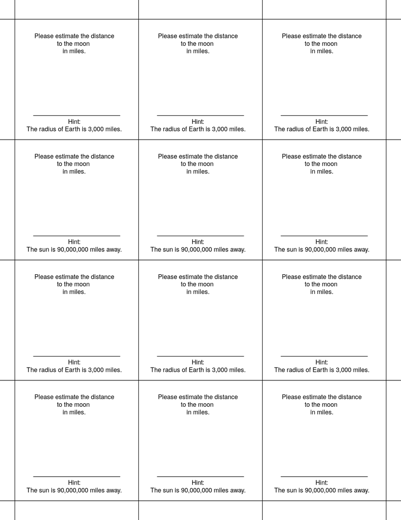

The statistical analysis took two forms: Welch’s $t$ test and an approximate permutation method.

## Results

The sample data are shown here.

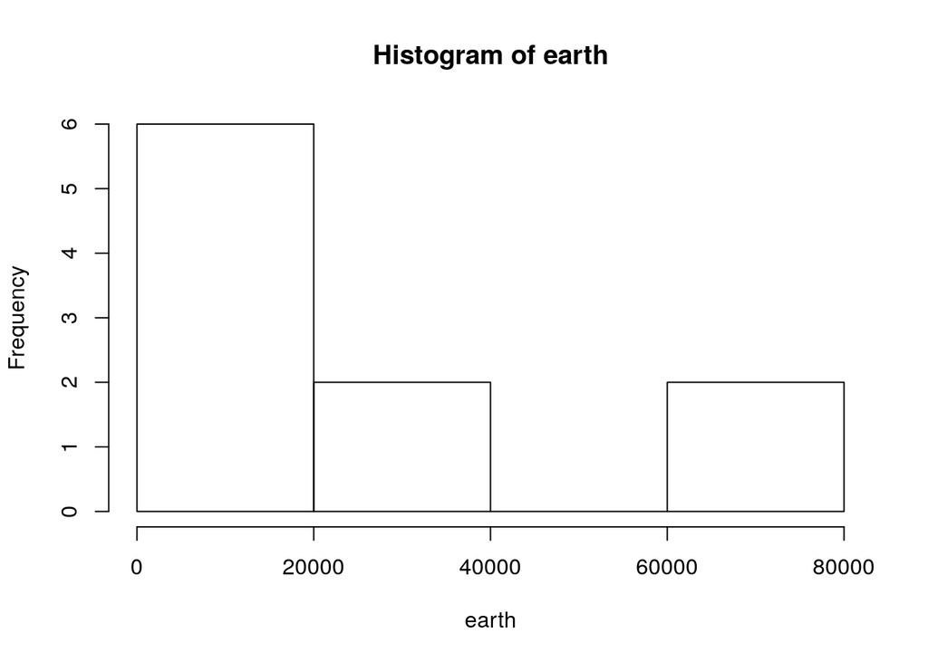

```r
earth = c(7.5e4,2e4,299,39590,3900,75000,30000,8197,15836,8100)
sun = c(1.23e7,1.85e5,2.2e5,45730003,1.2e5,6e5,4e8,2.05e7,48372213,3e5)
hist(earth)
```

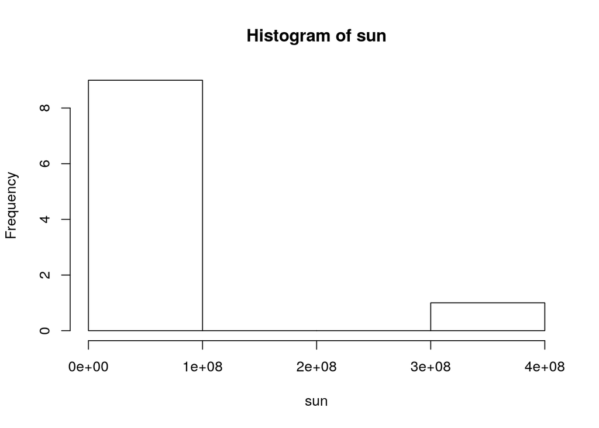

```r
hist(sun)
```

Notice both of these groups appear to have a heavy skew, so we should be wary of using an approach that assumes (repeated) small samples would be normally distributed. We continue with the Welch’s $t$ test as an exercise.

We find the means and sample standard deviations.

```r
xbar1 = mean(earth)
s1 = sd(earth)
n1 = length(earth)
xbar2 = mean(sun)
s2 = sd(sun)
n2 = length(sun)
```

| Group | Mean | Standard deviation | Size |
| --- | --- | --- | --- |
| Earth | $2.75922\times 10^{4}$ | $2.7694669\times 10^{4}$ | $10$ |
| Sun | $5.2832722\times 10^{7}$ | $1.2341899\times 10^{8}$ | $10$ |

## Discussion

```r
t.test(earth,sun)
```

```
    Welch Two Sample t-test

data:  earth and sun
t = -1.353, df = 9, p-value = 0.2091
alternative hypothesis: true difference in means is not equal to 0
95 percent confidence interval:
 -141093758   35483499
sample estimates:
 mean of x  mean of y
   27592.2 52832721.6
```

```r
nshuffles = 1000000
od = xbar2-xbar1
rds = vector("numeric", length=nshuffles)
for(i in 1:nshuffles)
{
    tot1 = sum(sample(c(earth,sun),n1))
    tot2 = sum(c(earth,sun))-tot1
    mean1 = tot1/n1
    mean2 = tot2/n2
    rds[i] = mean2-mean1
}
print(sum(abs(rds)>=abs(od))/nshuffles)
```

```
[1] 9e-06
```

```r
od
```

```
[1] 52805129
```

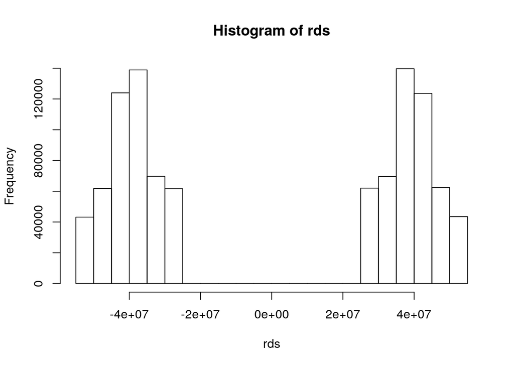

```r
hist(rds)
```

Notice the resampling does NOT look normal.

Notice that all numbers in group 1 are lower than the lowest in group 2. If 20 different numbers are split into two piles of 10, the chance that all 10 highest end up in group 2 can be calculated.
$$Pr = \frac{10!10!}{20!} = 5.4125441\times 10^{-6}$$